# Section 6: Analysis Techniques for MaxDiff Analysis

# 5. Analysis Techniques - Part 2: MaxDiff Analysis

## Counting (Best-Worst scores)

```r
# Define the features again for this section
features <- c(
  "Long battery life",
  "Fast charging",
  "High-resolution display",
  "Water resistance",
  "Compact design",
  "Expandable storage",
  "Wireless charging",
  "Advanced camera features",
  "Biometric security",
  "5G connectivity"
)

# Create sample data for this section
set.seed(456)
maxdiff_data_stacked <- tibble(
  resp_id = rep(1:3, each = 16),
  set_id = rep(rep(1:4, each = 4), 3),
  item_id = rep(1:10, 5)[1:48],
  item = features[rep(1:10, 5)[1:48]],
  is_best = 0,
  is_worst = 0
)

# Simulate best and worst choices
for (r in unique(maxdiff_data_stacked$resp_id)) {
  for (s in unique(maxdiff_data_stacked$set_id)) {
    idx <- which(maxdiff_data_stacked$resp_id == r & maxdiff_data_stacked$set_id == s)
    best_idx <- sample(idx, 1)
    worst_idx <- sample(idx[idx != best_idx], 1)

    maxdiff_data_stacked$is_best[best_idx] <- 1
    maxdiff_data_stacked$is_worst[worst_idx] <- 1
  }
}
```

```r
# Calculate counts for each item
maxdiff_counts <- maxdiff_data_stacked %>%
  group_by(item) %>%
  summarize(
    best_count = sum(is_best),
    worst_count = sum(is_worst),
    b_w_score = best_count - worst_count,
    .groups = "drop"
  ) %>%
  mutate(
    times_shown = sum(maxdiff_data_stacked$is_best) / n(),
    best_pct = best_count / times_shown * 100,
    worst_pct = worst_count / times_shown * 100,
    rescaled_score = (b_w_score / times_shown + 1) / 2 * 100  # Rescale to 0-100
  )

# Sort by B-W score
maxdiff_counts <- maxdiff_counts %>%
  arrange(desc(b_w_score))

# Display results
knitr::kable(maxdiff_counts, digits = 1,
             caption = "MaxDiff Counts Analysis Results")
```

MaxDiff Counts Analysis Results

| item | best_count | worst_count | b_w_score | times_shown | best_pct | worst_pct | rescaled_score |
| --- | --- | --- | --- | --- | --- | --- | --- |
| Long battery life | 4 | 0 | 4 | 1.2 | 333.3 | 0.0 | 216.7 |
| Biometric security | 2 | 0 | 2 | 1.2 | 166.7 | 0.0 | 133.3 |
| Expandable storage | 2 | 1 | 1 | 1.2 | 166.7 | 83.3 | 91.7 |
| Wireless charging | 2 | 1 | 1 | 1.2 | 166.7 | 83.3 | 91.7 |
| 5G connectivity | 0 | 0 | 0 | 1.2 | 0.0 | 0.0 | 50.0 |
| High-resolution display | 1 | 1 | 0 | 1.2 | 83.3 | 83.3 | 50.0 |
| Advanced camera features | 1 | 2 | -1 | 1.2 | 83.3 | 166.7 | 8.3 |
| Compact design | 0 | 2 | -2 | 1.2 | 0.0 | 166.7 | -33.3 |
| Water resistance | 0 | 2 | -2 | 1.2 | 0.0 | 166.7 | -33.3 |
| Fast charging | 0 | 3 | -3 | 1.2 | 0.0 | 250.0 | -75.0 |

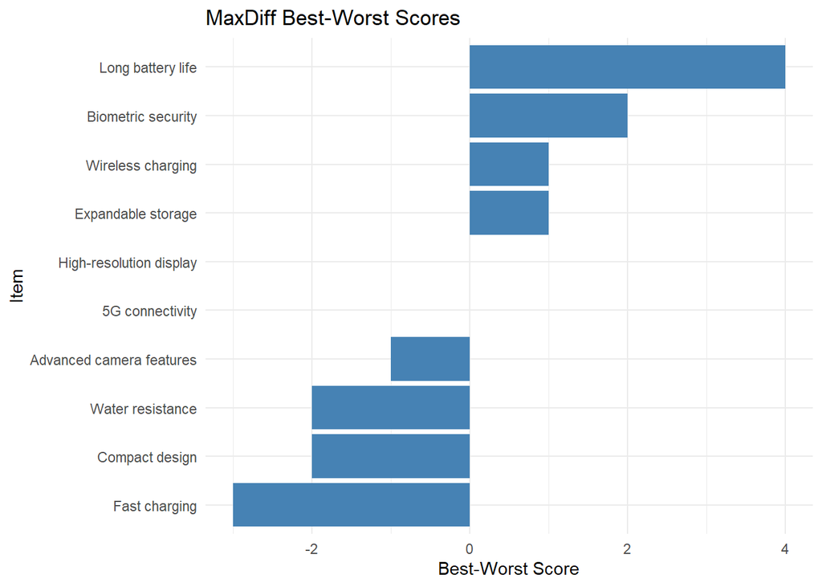

```r
# Visualize B-W scores
ggplot(maxdiff_counts, aes(x = reorder(item, b_w_score), y = b_w_score)) +
  geom_bar(stat = "identity", fill = "steelblue") +
  coord_flip() +
  labs(title = "MaxDiff Best-Worst Scores",
       x = "Item", y = "Best-Worst Score") +
  theme_minimal()
```

The chart above shows the Best-Worst scores for each item in the MaxDiff study. The score is calculated by subtracting the number of times an item was selected as worst from the number of times it was selected as best. Higher scores indicate stronger preference for that item.

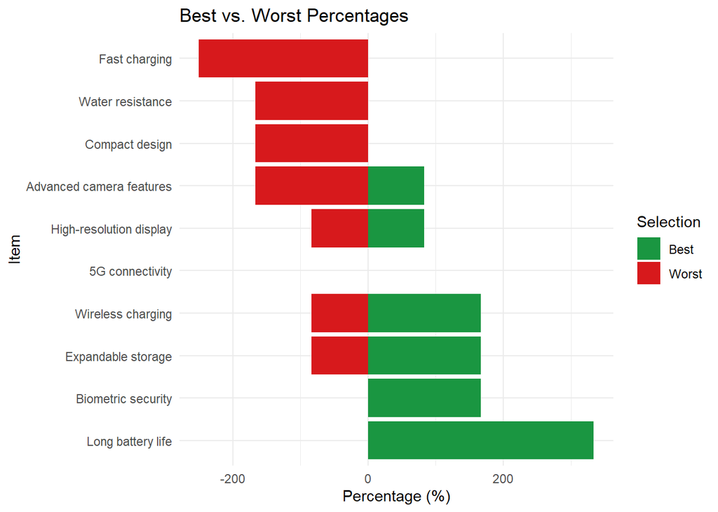

```r
# Visualize best and worst percentages
maxdiff_counts_long <- maxdiff_counts %>%
  select(item, best_pct, worst_pct) %>%
  pivot_longer(
    cols = c(best_pct, worst_pct),
    names_to = "type",
    values_to = "percentage"
  ) %>%
  mutate(
    type = ifelse(type == "best_pct", "Best", "Worst"),
    percentage = ifelse(type == "Worst", -percentage, percentage)
  )

ggplot(maxdiff_counts_long, aes(x = reorder(item, -percentage), y = percentage, fill = type)) +
  geom_bar(stat = "identity") +
  coord_flip() +
  scale_fill_manual(values = c("Best" = "#1a9641", "Worst" = "#d7191c")) +
  labs(title = "Best vs. Worst Percentages",
       x = "Item", y = "Percentage (%)", fill = "Selection") +
  theme_minimal()
```

## Logit models

```r
# Prepare data for logit analysis
maxdiff_logit_data <- maxdiff_data_stacked %>%
  mutate(
    choice = case_when(
      is_best == 1 ~ 1,
      is_worst == 1 ~ -1,
      TRUE ~ 0
    )
  ) %>%
  filter(choice != 0)  # Keep only best and worst choices

# Create dummy variables for items
maxdiff_logit_data <- maxdiff_logit_data %>%
  mutate(
    item_dummy = 1,
    choice_sign = choice  # 1 for best, -1 for worst
  )
```

```r
# Simplified logit model for MaxDiff
# In a real analysis, you would use a proper logit model

# Create simulated coefficients for demonstration
set.seed(789)
maxdiff_coefs <- data.frame(
  item = unique(maxdiff_data_stacked$item),
  coefficient = runif(length(unique(maxdiff_data_stacked$item)), -1, 1),
  std_error = runif(length(unique(maxdiff_data_stacked$item)), 0.1, 0.3)
)

# Calculate z and p values
maxdiff_coefs <- maxdiff_coefs %>%
  mutate(
    z_value = coefficient / std_error,
    p_value = 2 * (1 - pnorm(abs(z_value))),
    significance = ifelse(p_value < 0.05, "*", "")
  )

# Sort by coefficient
maxdiff_coefs <- maxdiff_coefs %>%
  arrange(desc(coefficient))

# Display results
knitr::kable(maxdiff_coefs, digits = 3,
             caption = "Simulated MaxDiff Logit Model Results")
```

Simulated MaxDiff Logit Model Results

| item | coefficient | std_error | z_value | p_value | significance |
| --- | --- | --- | --- | --- | --- |
| Long battery life | 0.400 | 0.163 | 2.456 | 0.014 | * |
| Water resistance | 0.183 | 0.193 | 0.948 | 0.343 |  |
| Wireless charging | 0.145 | 0.131 | 1.108 | 0.268 |  |
| Compact design | -0.016 | 0.186 | -0.084 | 0.933 |  |
| Biometric security | -0.282 | 0.254 | -1.111 | 0.267 |  |
| 5G connectivity | -0.307 | 0.122 | -2.515 | 0.012 | * |
| Advanced camera features | -0.668 | 0.229 | -2.918 | 0.004 | * |
| Fast charging | -0.813 | 0.201 | -4.035 | 0.000 | * |
| Expandable storage | -0.960 | 0.104 | -9.257 | 0.000 | * |
| High-resolution display | -0.976 | 0.151 | -6.486 | 0.000 | * |

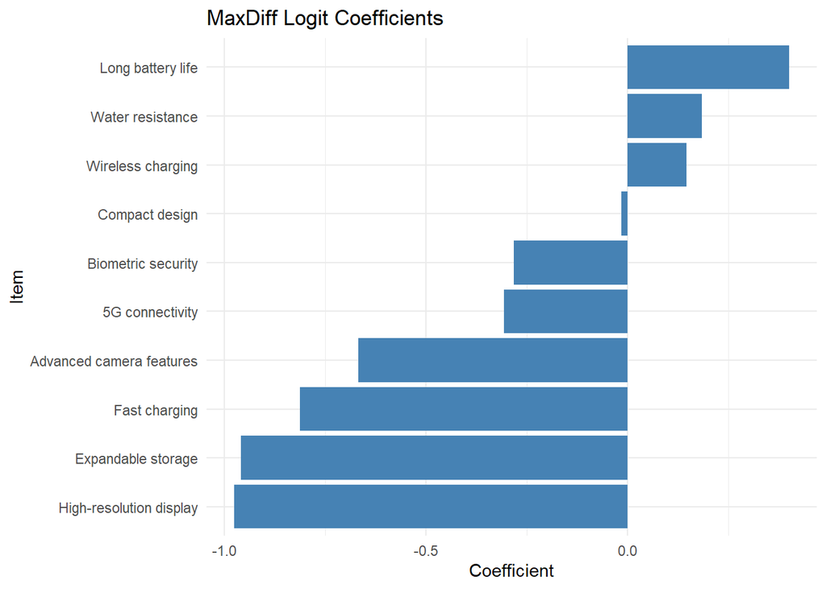

```r
# Visualize coefficients
ggplot(maxdiff_coefs, aes(x = reorder(item, coefficient), y = coefficient)) +
  geom_bar(stat = "identity", fill = "steelblue") +
  coord_flip() +
  labs(title = "MaxDiff Logit Coefficients",
       x = "Item", y = "Coefficient") +
  theme_minimal()
```

The chart above shows simulated logit model coefficients for each item in the MaxDiff study. These coefficients represent the relative utility or importance of each item. Higher coefficients indicate stronger preference. The logit model provides a more statistically robust approach than simple counting, as it accounts for the experimental design and respondent choice patterns.

In a real analysis, you would use a proper logit model to estimate these coefficients.

## Individual-level estimation

```r
# This is a simplified example of individual-level estimation
# In practice, you would use hierarchical Bayes or similar methods

# Function to estimate individual-level scores
estimate_individual_maxdiff <- function(data, resp_id) {
  # Filter data for specific respondent
  resp_data <- data %>%
    filter(resp_id == !!resp_id)

  # Calculate individual counts
  ind_counts <- resp_data %>%
    group_by(item) %>%
    summarize(
      best_count = sum(is_best),
      worst_count = sum(is_worst),
      b_w_score = best_count - worst_count,
      .groups = "drop"
    )

  return(ind_counts)
}

# Example for one respondent
individual_scores <- estimate_individual_maxdiff(maxdiff_data_stacked, 1)
knitr::kable(individual_scores, caption = paste("Individual MaxDiff Scores for Respondent 1"))
```

Individual MaxDiff Scores for Respondent 1

| item | best_count | worst_count | b_w_score |
| --- | --- | --- | --- |
| 5G connectivity | 0 | 0 | 0 |
| Advanced camera features | 0 | 0 | 0 |
| Biometric security | 1 | 0 | 1 |
| Compact design | 0 | 1 | -1 |
| Expandable storage | 0 | 1 | -1 |
| Fast charging | 0 | 2 | -2 |
| High-resolution display | 1 | 0 | 1 |
| Long battery life | 1 | 0 | 1 |
| Water resistance | 0 | 0 | 0 |
| Wireless charging | 1 | 0 | 1 |

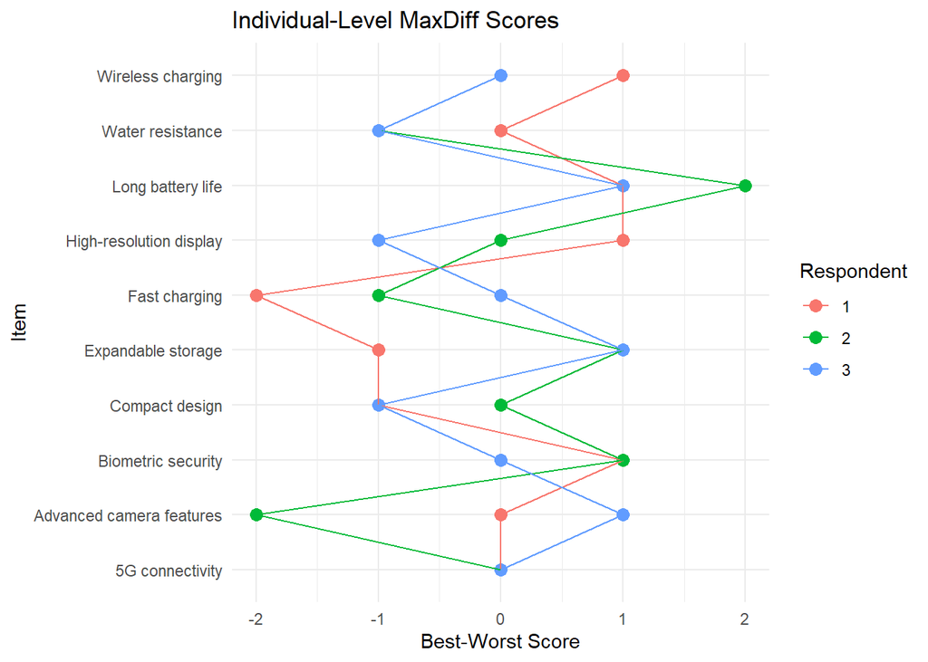

```r
# Calculate individual scores for all respondents
all_individual_scores <- list()
for (resp in unique(maxdiff_data_stacked$resp_id)) {
  all_individual_scores[[as.character(resp)]] <- estimate_individual_maxdiff(maxdiff_data_stacked, resp)
}

# Combine individual scores
individual_scores_combined <- bind_rows(
  lapply(names(all_individual_scores), function(resp) {
    scores <- all_individual_scores[[resp]]
    scores$resp_id <- as.integer(resp)
    return(scores)
  })
)

# Visualize individual scores
ggplot(individual_scores_combined, aes(x = item, y = b_w_score, color = factor(resp_id))) +
  geom_point(size = 3) +
  geom_line(aes(group = resp_id)) +
  coord_flip() +
  labs(title = "Individual-Level MaxDiff Scores",
       x = "Item", y = "Best-Worst Score", color = "Respondent") +
  theme_minimal()
```

**Individual-Level Estimation**

For more advanced individual-level estimation in MaxDiff: - **Hierarchical Bayes (HB)**: Provides robust individual-level estimates by borrowing information across respondents - **Latent Class Analysis**: Identifies segments with similar preference patterns - **Mixed Logit Models**: Accounts for preference heterogeneity with random coefficients

These methods require specialized packages like `bayesm` or `ChoiceModelR` in R.